# Practice Exam 1

Tyler Simko

9/22/2020

This practice exam uses data from the College Scorecard, a public dataset from the US Department of Education that contains information about colleges and universities in the United States. Here is the link to where the dataset was acquired:

https://collegescorecard.ed.gov/data/

The relevant columns for this practice exam are described below:

| Name | Description |
| --- | --- |
| `name` | Name. |
| `state` | State. |
| `region` | US region. |
| `campuses` | Number of campuses. |
| `id` | Institution ID - shared between campuses. |
| `id_long` | Longer ID - unique to every row. |
| `class` | College-type indicator. |
| `locale` | City, town, rural, etc. |
| `ug_enrollment` | Number of enrolled undergraduates 2020. |
| `main_campus` | 1 if main campus, 0 otherwise. |
| `hbcu` | Historically Black College / University. |
| `women_only` | Women-only college / university. |
| `religious_affiliation` | 1 if religiously affiliated, NA otherwise. |
| `admission_rate` | Overall admission rate. |
| `social_sciences` | Percentage of all degrees in social sciences. |
| `physical_sciences` | Percentage of all degrees in physical sciences. |
| `ethnic_gender_sciences` | Percentage of all degrees in ethnic, gender, group, or cultural studies. |
| `comp_sci` | Percentage of all degrees in computer science. |
| `avg_faculty_salary` | Average monthly faculty salary. |
| `completion_rate` | Average 4-year completion rate. |
| `pell_grant` | Percentage of undergraduates on a Pell Grant. |
| `first_gen_completion_4` | Percentage of first-gen students who complete degree in 4 years. |

## Question 1

Make a new .Rmd file called `exam_1.Rmd`. I put a .csv file on Canvas under Files –> Practice Exam 1 called `college_scorecard.csv`. Download this file, place it in a new folder called `raw_data`, and read it into a `tibble` called `colleges`. Make sure to set the `col_types` argument so that no message appears when you read the data.

Then, make a new object called `q1` which contains only the `name` and `pell_grant` columns for the 10 New Jersey colleges / universities with the largest proportion of undergraduates receiving Pell Grants.

## Question 2

1. `religious_num` = the number of colleges and universities with a religious affiliation in each region of the US
2. `religious_prop` = the **proportion** of all colleges and universities in that region that have a religious affiliation.

Save all of this into a new dataset called `regional_religion`.

## Question 3

Use the `regional_religion` dataset to replicate the following plot.

The theme is `theme_bw()` and the color of the bars is “#69A297”. You’ll also need to remove the “US Service Schools” region. Use the `breaks` and `labels` argument in a scale function for the y-axis to change the default numeric labels to the nicer character ones below.

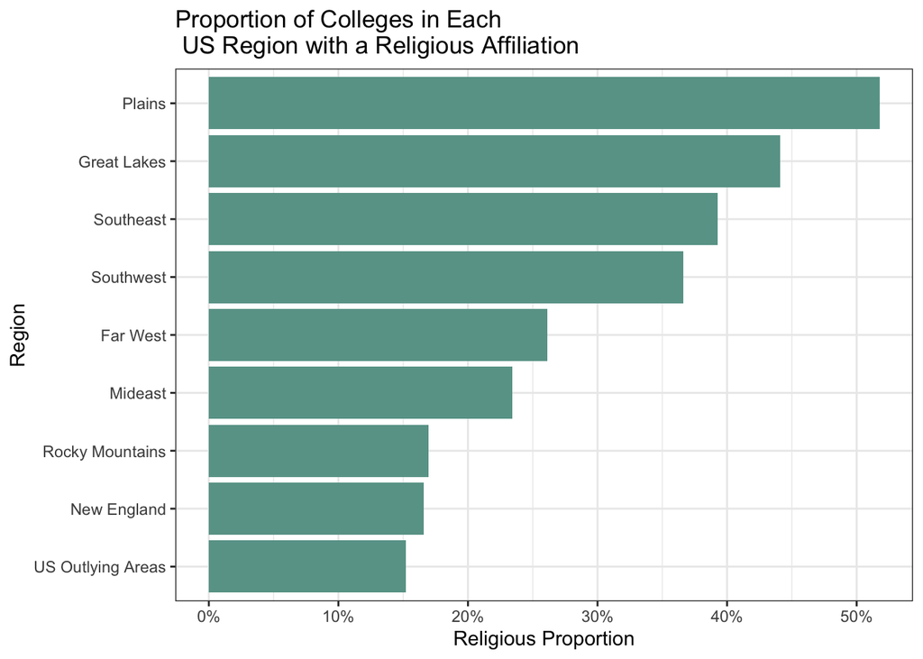

## Question 5

Load the `fec16` library from Problem Set 2. Create a new object called `avg_results` that calculates the average `general_percent` for Democratic candidates in every state (you will need to set `na.rm = TRUE` in your `mean` call) using the `results_house` dataset.

Next, create a new object called `avg_pell` that calculates the average percentage of undergraduates enrolled in each state receiving Pell Grants. Remove the “GU” and “VI” states.

Finally, join these two objects into an object called `q5` so that rows are maintained only if they appear in both datasets.

## Question 6

Create an object called `avg_first` that:

1. Keeps only observations in `colleges` that are not in state “GU” (Guam), not in state “VI” (Virgin Islands), and have non-NA values in `first_gen_completion_4` (remember `!is.na()`).
2. Creates a summarized dataset that finds the average of the `first_gen_completion_4` column within each `state` and `locale`.

Store this 213 rows by 3 columns dataset in `avg_first`.